# Clustering 1: Puntos en el plano

1. Complete

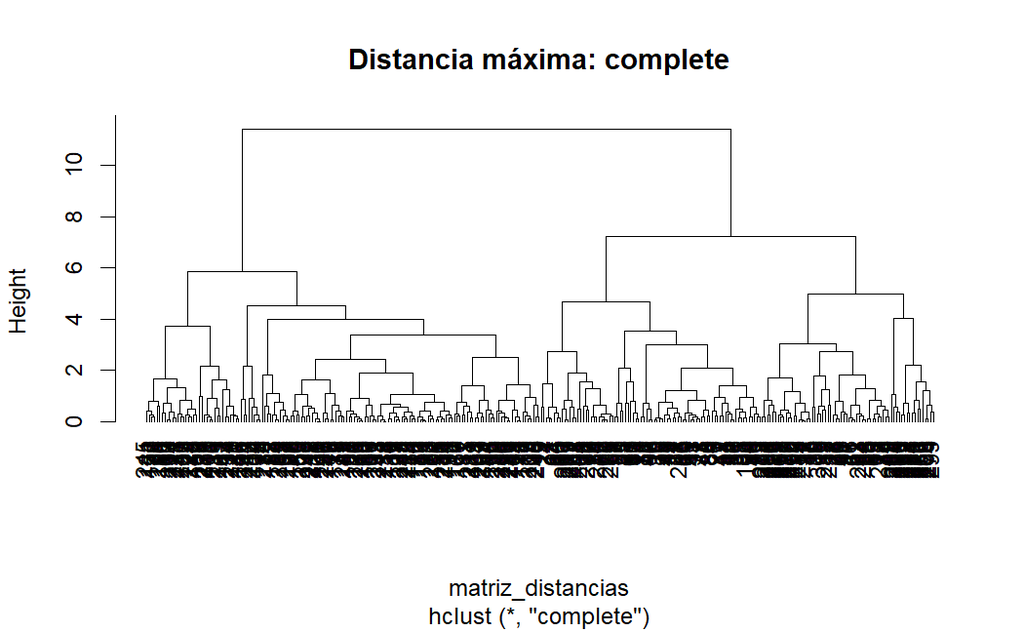

```r
hclust_complete <- hclust(matriz_distancias, method="complete")
plot(hclust_complete, main="Distancia máxima: complete", hang=-2)
```

2. Average

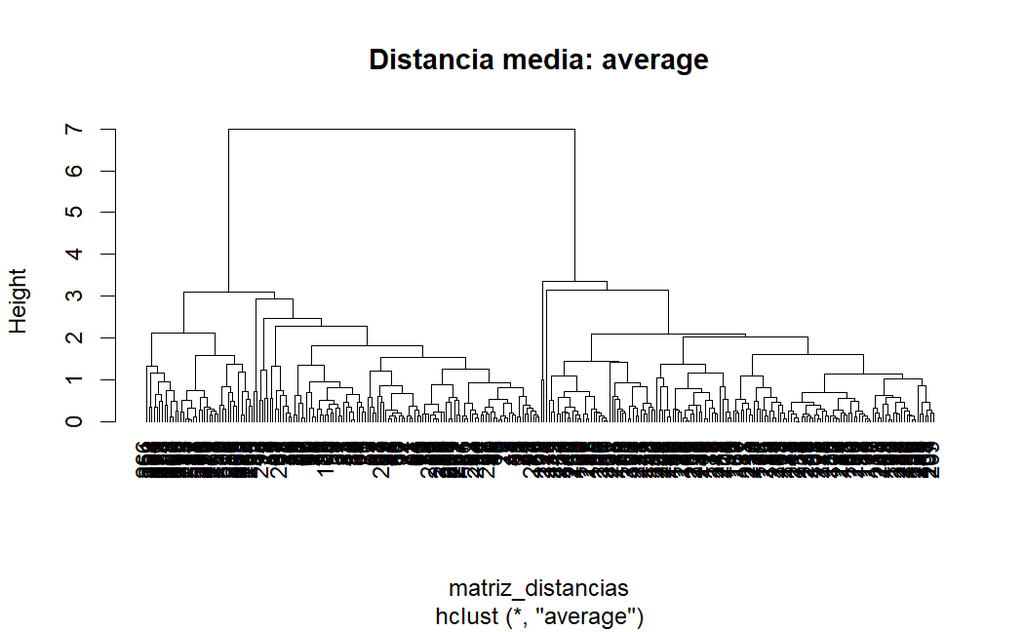

```r
hclust_average <- hclust(matriz_distancias, method="average")
plot(hclust_average, main="Distancia media: average", hang=-2)
```

3. Single

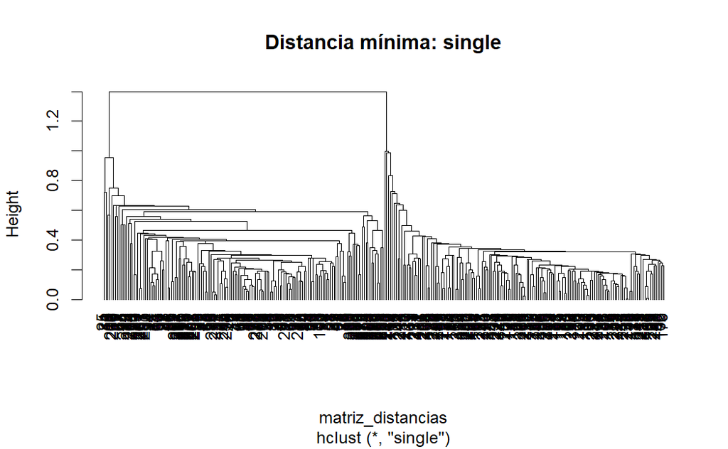

```r
hclust_single <- hclust(matriz_distancias, method="single")
plot(hclust_single, main="Distancia mínima: single", hang=-2)
```

### Comentario:

Comprobamos que el dataset de puntos esté bien escalado. En este caso están bien escalados en las dos dimensiones. Si no se diese así, habría qeu hacer un escalado previo a la aplicación del algoritmo. No tiene sentido plantearse un clustering con valores de x e y en muy diferentes escalas-

```r
#Mostrar la escala de valores
colMeans(puntos)
```

```
       V1        V2
-1.688446  1.639156
```

```r
#Si se requierese escalado
puntos_escalados <- scale(puntos)
colMeans(puntos_escalados)
```

```
           V1            V2
-8.413409e-18  6.411538e-17
```

# Comparamos los resultados de los dos algoritmos

Vemos los clusteres de kMeans y los del Jerárquico y vemos la relación.

```r
table(km_puntos$cluster, cutree(hclust_aux, k=2))
```

```
      1   2
  1   0 150
  2  98   0
  3  52   0
```

Los valores (i,j) representan el número de puntos que se reparten en los clusteres i,j de cada algoritmo.

```r
table(km_puntos$cluster, #filas=algoritmo kmeans
      cutree(hclust_aux, k=3)) #columnas= algoritmo jerarquico
```

```
      1   2   3
  1   0   0 150
  2  79  19   0
  3   5  47   0
```

Por ejemplo, si fijo las filas, observaré “del cluster i del kMeans, se reparten tantos puntos en los clusters j del Jerárquico”.